# Marketing Campaigns of Portuguese Bank

Predict client subscription

Denaldo Lapi, Francesco Aristei, Samy Chouiti

10 June 2022

Delete all the possible objects of R that could have been left in memory:

```r
rm(list = ls())
```

### 0.0.1 Load packages

```r
library(dplyr)
library(ggplot2)
library(kableExtra)
library(gridExtra)
library(stats)
library(gplots)
library(factoextra)
library(FactoMineR)
```

# 1 Exploratory data analysis

The dataset we are going to use is related with direct marketing campaigns (phone calls) of a Portuguese banking institution. The classification goal is to predict if the client will subscribe a term deposit (variable y). A brief description of each variable:

BANK CLIENT DATA:

- age (numeric)
- job : type of job (categorical: ‘admin.’,‘blue-collar’,‘entrepreneur’,‘housemaid’,‘management’,‘retired’,‘self-employed’,‘services’,‘student’,‘technician’,‘unemployed’,‘unknown’)
- marital : marital status (categorical: ‘divorced’,‘married’,‘single’,‘unknown’)
- education (categorical)
- default: has credit in default? (categorical: ‘no’,‘yes’,‘unknown’)
- balance: bank balance (numeric)
- housing: has housing loan? (categorical: ‘no’,‘yes’,‘unknown’)
- loan: has personal loan? (categorical: ‘no’,‘yes’,‘unknown’)

RELATED WITH THE LAST CONTACT OF THE CURRENT CAMPAIGN: * contact: contact communication type (categorical: ‘cellular’,‘telephone’) * month: last contact month of year (categorical: ‘jan’, ‘feb’, ‘mar’, …, ‘nov’, ‘dec’) * day: last contact day of the week (numeric) * duration: last contact duration, in seconds (numeric).

OTHER ATTRIBUTES

- campaign: number of contacts performed during this campaign and for this client (numeric)
- pdays: number of days that passed by after the client was last contacted from a previous campaign. (numeric)
- previous: number of contacts performed before this campaign and for this client (numeric)
- poutcome: outcome of the previous marketing campaign (categorical: ‘failure’,‘nonexistent’,‘success’)

OUTPUT VARIABLE

- y has the client subscribed a term deposit? (binary: ‘yes’,‘no’)

At first let’s load the data:

```r
data = read.csv("bank.csv", sep = ";", header = TRUE)
```

Since the data matrix contains one observation for each customer, we identify each individual with a progressive integer ID:

```r
data$ID <- seq.int(nrow(data))
```

We can reorder columns in order to have the id column as the first one:

```r
data <- data %>%
  select(ID, everything())
```

```r
head(data)
```

| ID | age | job | marital | education | default | balance | housing | loan | contact | day | month | duration | campaign | pdays | previous | poutcome | y |
| --- | --- | --- | --- | --- | --- | --- | --- | --- | --- | --- | --- | --- | --- | --- | --- | --- | --- |
| 1 | 30 | unemployed | married | primary | no | 1787 | no | no | cellular | 19 | oct | 79 | 1 | -1 | 0 | unknown | no |
| 2 | 33 | services | married | secondary | no | 4789 | yes | yes | cellular | 11 | may | 220 | 1 | 339 | 4 | failure | no |
| 3 | 35 | management | single | tertiary | no | 1350 | yes | no | cellular | 16 | apr | 185 | 1 | 330 | 1 | failure | no |
| 4 | 30 | management | married | tertiary | no | 1476 | yes | yes | unknown | 3 | jun | 199 | 4 | -1 | 0 | unknown | no |
| 5 | 59 | blue-collar | married | secondary | no | 0 | yes | no | unknown | 5 | may | 226 | 1 | -1 | 0 | unknown | no |
| 6 | 35 | management | single | tertiary | no | 747 | no | no | cellular | 23 | feb | 141 | 2 | 176 | 3 | failure | no |

Check dimension:

```r
dim(data)
```

```
## [1] 4521   18
```

The dataset was correctly read: it has 4521 rows/observations and 18 columns/variables

Check the structure:

```r
str(data)
```

```
## 'data.frame':    4521 obs. of  18 variables:
##  $ ID       : int  1 2 3 4 5 6 7 8 9 10 ...
##  $ age      : int  30 33 35 30 59 35 36 39 41 43 ...
##  $ job      : chr  "unemployed" "services" "management" "management" ...
##  $ marital  : chr  "married" "married" "single" "married" ...
##  $ education: chr  "primary" "secondary" "tertiary" "tertiary" ...
##  $ default  : chr  "no" "no" "no" "no" ...
##  $ balance  : int  1787 4789 1350 1476 0 747 307 147 221 -88 ...
##  $ housing  : chr  "no" "yes" "yes" "yes" ...
##  $ loan     : chr  "no" "yes" "no" "yes" ...
##  $ contact  : chr  "cellular" "cellular" "cellular" "unknown" ...
##  $ day      : int  19 11 16 3 5 23 14 6 14 17 ...
##  $ month    : chr  "oct" "may" "apr" "jun" ...
##  $ duration : int  79 220 185 199 226 141 341 151 57 313 ...
##  $ campaign : int  1 1 1 4 1 2 1 2 2 1 ...
##  $ pdays    : int  -1 339 330 -1 -1 176 330 -1 -1 147 ...
##  $ previous : int  0 4 1 0 0 3 2 0 0 2 ...
##  $ poutcome : chr  "unknown" "failure" "failure" "unknown" ...
##  $ y        : chr  "no" "no" "no" "no" ...
```

As we can see, all categorical variables has been read as ‘character’ by R, so let’s transform them into the ‘factor’ R data type:

```r
data[,"job"] = as.factor(data[,"job"])
data[,"marital"] = as.factor(data[,"marital"])
data[,"education"] = as.factor(data[,"education"])
data[,"default"] = as.factor(data[,"default"])
data[,"housing"] = as.factor(data[,"housing"])
data[,"loan"] = as.factor(data[,"loan"])
data[,"contact"] = as.factor(data[,"contact"])
data[,"month"] = as.factor(data[,"month"])
data[,"poutcome"] = as.factor(data[,"poutcome"])
data[,"y"] = as.factor(data[,"y"])
```

We can check again the structure:

```r
str(data)
```

```
## 'data.frame':    4521 obs. of  18 variables:
##  $ ID       : int  1 2 3 4 5 6 7 8 9 10 ...
##  $ age      : int  30 33 35 30 59 35 36 39 41 43 ...
##  $ job      : Factor w/ 12 levels "admin.","blue-collar",..: 11 8 5 5 2 5 7 10 3 8 ...
##  $ marital  : Factor w/ 3 levels "divorced","married",..: 2 2 3 2 2 3 2 2 2 2 ...
##  $ education: Factor w/ 4 levels "primary","secondary",..: 1 2 3 3 2 3 3 2 3 1 ...
##  $ default  : Factor w/ 2 levels "no","yes": 1 1 1 1 1 1 1 1 1 1 ...
##  $ balance  : int  1787 4789 1350 1476 0 747 307 147 221 -88 ...
##  $ housing  : Factor w/ 2 levels "no","yes": 1 2 2 2 2 1 2 2 2 2 ...
##  $ loan     : Factor w/ 2 levels "no","yes": 1 2 1 2 1 1 1 1 1 2 ...
##  $ contact  : Factor w/ 3 levels "cellular","telephone",..: 1 1 1 3 3 1 1 1 3 1 ...
##  $ day      : int  19 11 16 3 5 23 14 6 14 17 ...
##  $ month    : Factor w/ 12 levels "apr","aug","dec",..: 11 9 1 7 9 4 9 9 9 1 ...
##  $ duration : int  79 220 185 199 226 141 341 151 57 313 ...
##  $ campaign : int  1 1 1 4 1 2 1 2 2 1 ...
##  $ pdays    : int  -1 339 330 -1 -1 176 330 -1 -1 147 ...
##  $ previous : int  0 4 1 0 0 3 2 0 0 2 ...
##  $ poutcome : Factor w/ 4 levels "failure","other",..: 4 1 1 4 4 1 2 4 4 1 ...
##  $ y        : Factor w/ 2 levels "no","yes": 1 1 1 1 1 1 1 1 1 1 ...
```

```r
data %>%
  sample_n(., 10, replace=FALSE) %>%
  kbl(caption = "Marketing Campaigns of Portuguese Bank (sample of 20)") %>%
  kable_classic(full_width = F, html_font = "Cambria")
```

| ID | age | job | marital | education | default | balance | housing | loan | contact | day | month | duration | campaign | pdays | previous | poutcome | y |
| --- | --- | --- | --- | --- | --- | --- | --- | --- | --- | --- | --- | --- | --- | --- | --- | --- | --- |
| 2291 | 38 | entrepreneur | married | tertiary | no | 228 | yes | no | cellular | 5 | feb | 105 | 1 | -1 | 0 | unknown | no |
| 3532 | 44 | management | divorced | tertiary | no | 0 | no | no | cellular | 22 | aug | 54 | 2 | -1 | 0 | unknown | no |
| 4174 | 25 | admin. | single | tertiary | no | 220 | no | no | cellular | 26 | may | 68 | 1 | -1 | 0 | unknown | no |
| 4503 | 42 | services | married | secondary | no | -91 | yes | yes | cellular | 5 | feb | 43 | 1 | -1 | 0 | unknown | no |
| 1054 | 47 | blue-collar | divorced | secondary | yes | -535 | yes | no | cellular | 30 | jul | 71 | 2 | -1 | 0 | unknown | no |
| 893 | 27 | student | single | tertiary | no | 5291 | no | no | cellular | 12 | nov | 192 | 2 | 92 | 2 | failure | yes |
| 414 | 42 | management | married | tertiary | no | 0 | no | no | cellular | 13 | aug | 325 | 2 | -1 | 0 | unknown | no |
| 3331 | 58 | blue-collar | married | secondary | no | 0 | no | yes | cellular | 14 | apr | 101 | 5 | -1 | 0 | unknown | no |
| 2420 | 41 | blue-collar | single | secondary | yes | -386 | no | yes | cellular | 20 | nov | 477 | 1 | -1 | 0 | unknown | yes |
| 1254 | 54 | entrepreneur | married | secondary | no | 653 | yes | no | unknown | 15 | may | 352 | 1 | -1 | 0 | unknown | no |

Let’s now visualize some basic statistics on each of the data frame’s columns with *summary*:

```r
data %>%
  summary(.) %>%
  kbl(caption = "Basic statistics. Marketing Campaigns of Portuguese Bank") %>%
  kable_classic(full_width = F, html_font = "Cambria")
```

Basic statistics. Marketing Campaigns of Portuguese Bank

|  | ID | age | job | marital | education | default | balance | housing | loan | contact | day | month | duration | campaign | pdays | previous | poutcome | y |
| --- | --- | --- | --- | --- | --- | --- | --- | --- | --- | --- | --- | --- | --- | --- | --- | --- | --- | --- |
|  | Min. : 1 | Min. :19.00 | management :969 | divorced: 528 | primary : 678 | no :4445 | Min. :-3313 | no :1962 | no :3830 | cellular :2896 | Min. : 1.00 | may :1398 | Min. : 4 | Min. : 1.000 | Min. : -1.00 | Min. : 0.0000 | failure: 490 | no :4000 |
|  | 1st Qu.:1131 | 1st Qu.:33.00 | blue-collar:946 | married :2797 | secondary:2306 | yes: 76 | 1st Qu.: 69 | yes:2559 | yes: 691 | telephone: 301 | 1st Qu.: 9.00 | jul : 706 | 1st Qu.: 104 | 1st Qu.: 1.000 | 1st Qu.: -1.00 | 1st Qu.: 0.0000 | other : 197 | yes: 521 |
|  | Median :2261 | Median :39.00 | technician :768 | single :1196 | tertiary :1350 | NA | Median : 444 | NA | NA | unknown :1324 | Median :16.00 | aug : 633 | Median : 185 | Median : 2.000 | Median : -1.00 | Median : 0.0000 | success: 129 | NA |
|  | Mean :2261 | Mean :41.17 | admin. :478 | NA | unknown : 187 | NA | Mean : 1423 | NA | NA | NA | Mean :15.92 | jun : 531 | Mean : 264 | Mean : 2.794 | Mean : 39.77 | Mean : 0.5426 | unknown:3705 | NA |
|  | 3rd Qu.:3391 | 3rd Qu.:49.00 | services :417 | NA | NA | NA | 3rd Qu.: 1480 | NA | NA | NA | 3rd Qu.:21.00 | nov : 389 | 3rd Qu.: 329 | 3rd Qu.: 3.000 | 3rd Qu.: -1.00 | 3rd Qu.: 0.0000 | NA | NA |
|  | Max. :4521 | Max. :87.00 | retired :230 | NA | NA | NA | Max. :71188 | NA | NA | NA | Max. :31.00 | apr : 293 | Max. :3025 | Max. :50.000 | Max. :871.00 | Max. :25.0000 | NA | NA |
|  | NA | NA | (Other) :713 | NA | NA | NA | NA | NA | NA | NA | NA | (Other): 571 | NA | NA | NA | NA | NA | NA |

The previous output allows to understand some important properties of the dataset. At first we can see the possible values assumed by each categorical variable.

### 1.0.1 Check for missing values

Let’s check for NA values for each column:

```r
colSums((is.na((data))))
```

```
##        ID       age       job   marital education   default   balance   housing
##         0         0         0         0         0         0         0         0
##      loan   contact       day     month  duration  campaign     pdays  previous
##         0         0         0         0         0         0         0         0
##  poutcome         y
##         0         0
```

There are no missing values!

### 1.0.2 Check variables distribution

Before dealing with outliers, we would like to better inspect the data at our disposal by directly visualizing the distribution of each variable. This will allow us to understand the characteristics of them and to decide the strategy to adopt for dealing with eventual outliers.

At first, let’s visualize the distribution of each qualitative variable, by using bar plots. Specifically, these plots are drawn taking into consideration the value of the ‘y’ variable. In this way we can already start to understand just by a visual inspection, the percentage of subscription to the term deposit, for the individuals in the data set, with respect to the value assumed by the variable under inspection.

‘job’ variable:

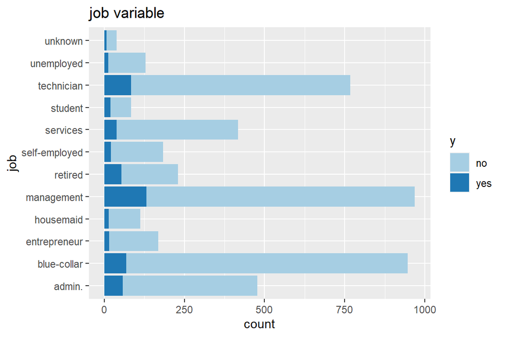

```r
p <- ggplot(data, aes(x=job, fill=y))+
  geom_bar(stat="count", width=0.9 )+
  labs(
    title = "job variable",
    x = "job",
    y = "count"
  )+
  scale_fill_brewer(palette="Paired")+
  theme_grey()

p + coord_flip()
```

Is already evident how for some specific type of occupations, the percentage of adhesion to the term deposit is greater than for other kind of jobs. For example, the individuals performing blue-collar or management jobs are less likely to adhere to the term deposit than for example retired people.

‘marital’ variable:

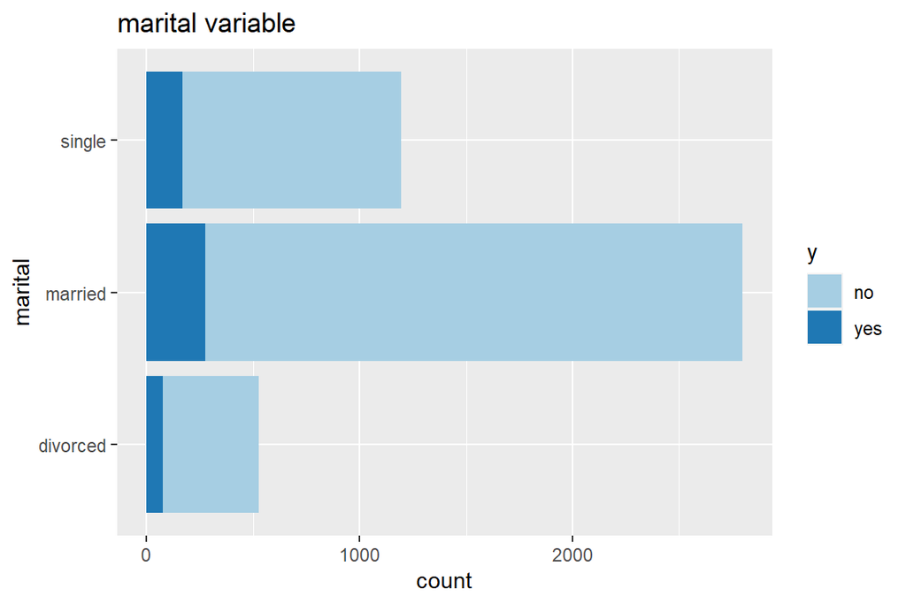

```r
p <- ggplot(data, aes(x=marital, fill=y))+
  geom_bar(stat="count", width=0.9 )+
  labs(
    title = "marital variable",
    x = "marital",
    y = "count"
  )+
  scale_fill_brewer(palette="Paired")+
  theme_grey()

p + coord_flip()
```

‘education’ variable:

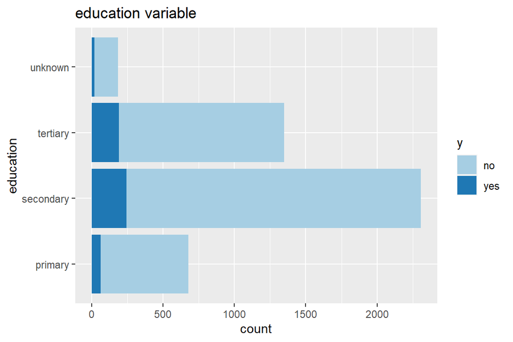

```r
p <- ggplot(data, aes(x=education, fill=y))+
  geom_bar(stat="count", width=0.9 )+
  labs(
    title = "education variable",
    x = "education",
    y = "count"
  )+
  scale_fill_brewer(palette="Paired")+
  theme_grey()

p + coord_flip()
```

‘default’ variable:

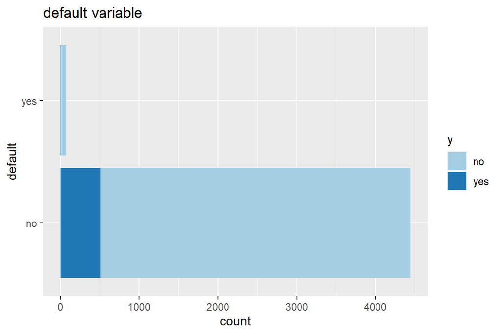

```r
p <- ggplot(data, aes(x=default, fill=y))+
  geom_bar(stat="count", width=0.9 )+
  labs(
    title = "default variable",
    x = "default",
    y = "count"
  )+
  scale_fill_brewer(palette="Paired")+
  theme_grey()

p + coord_flip()
```

‘housing’ variable:

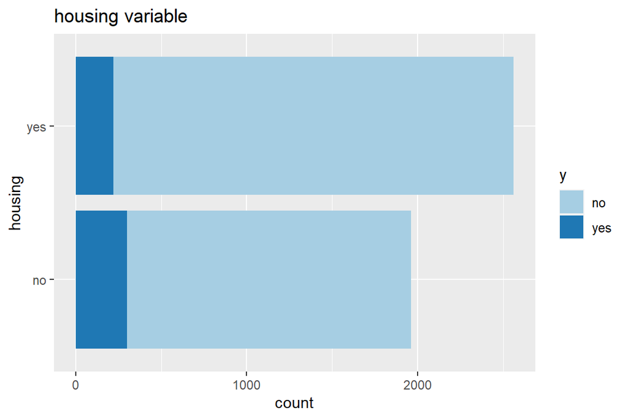

```r
p <- ggplot(data, aes(x=housing, fill=y))+
  geom_bar(stat="count", width=0.9 )+
  labs(
    title = "housing variable",
    x = "housing",
    y = "count"
  )+
  scale_fill_brewer(palette="Paired")+
  theme_grey()

p + coord_flip()
```

Observations: From the plot it can be observed how people having no housing loan are more prone to subscribe for the term deposit. This observation is coherent given that people who are already under a debt condition, needs more liquidity in the short term and cannot afford to keep it untouched in some kind of deposit instrument.

‘loan’ variable:

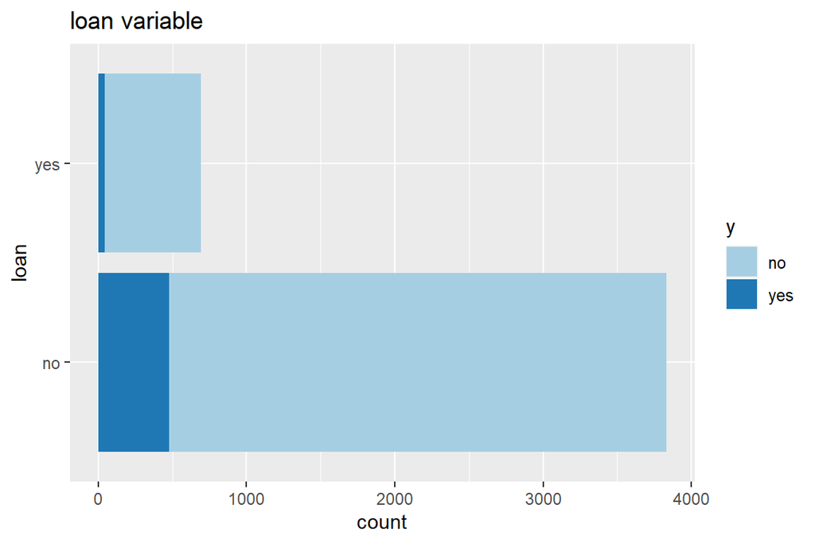

```r
p <- ggplot(data, aes(x=loan, fill=y))+
  geom_bar(stat="count", width=0.9 )+
  labs(
    title = "loan variable",
    x = "loan",
    y = "count"
  )+
  scale_fill_brewer(palette="Paired")+
  theme_grey()

p + coord_flip()
```

‘contact’ variable:

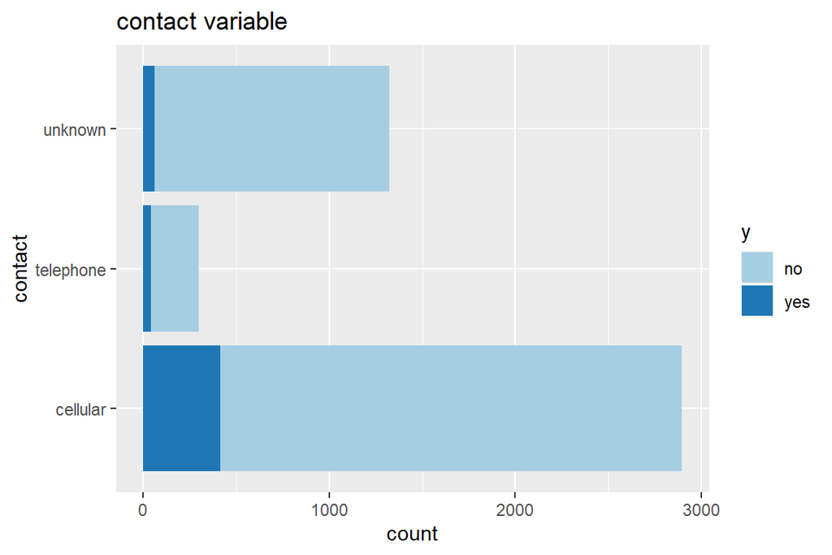

```r
p <- ggplot(data, aes(x=contact, fill=y))+
  geom_bar(stat="count", width=0.9 )+
  labs(
    title = "contact variable",
    x = "contact",
    y = "count"
  )+
  scale_fill_brewer(palette="Paired")+
  theme_grey()

p + coord_flip()
```

‘month’ variable:

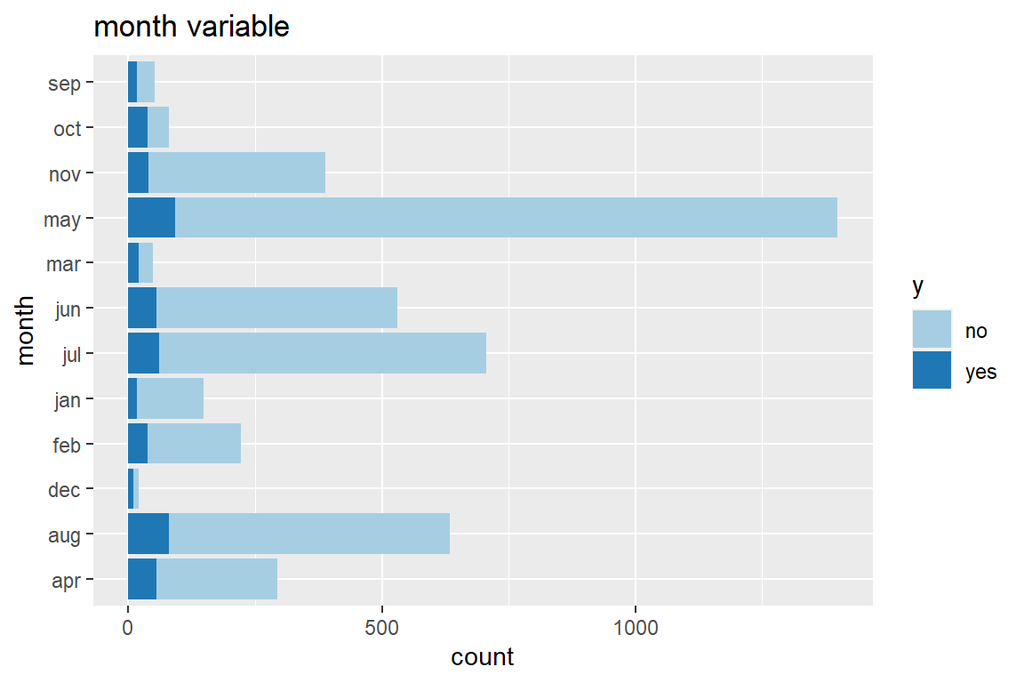

```r
p <- ggplot(data, aes(x=month, fill=y))+
  geom_bar(stat="count", width=0.9 )+
  labs(
    title = "month variable",
    x = "month",
    y = "count"
  )+
  scale_fill_brewer(palette="Paired")+
  theme_grey()

p + coord_flip()
```

Observations: * Most of the last contacts have happened in the month of may, or more generally, during the summer months, which may indicate also the starting period of the marketing campaign. * Interestingly, seems like people contacted in the month immediately after the months described above, have an higher possibility of signing for a term deposit.

‘poutcome’ variable:

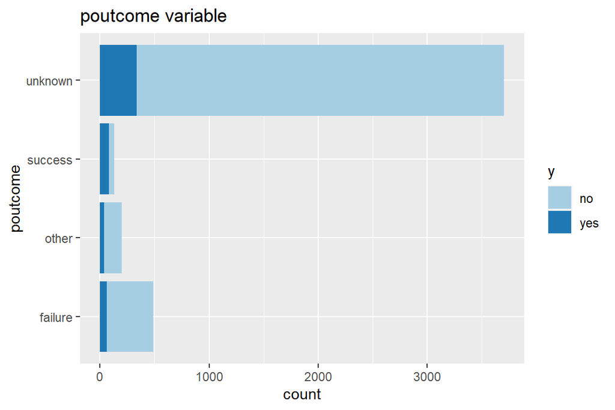

```r
p <- ggplot(data, aes(x=poutcome, fill=y))+
  geom_bar(stat="count", width=0.9 )+
  labs(
    title = "poutcome variable",
    x = "poutcome",
    y = "count"
  )+
  scale_fill_brewer(palette="Paired")+
  theme_grey()

p + coord_flip()
```

Observations: * As expected, people who decided to sign for a term deposit in a previous campaign are very prone to re-sign for the current campaign, however, most of the values are ‘unknown’, meaning that the outcome of the campaign for each client, weren’t tracked appropriately by the bank. * One thing who should be highlighted, is that there is some ambiguity on the meaning of ‘other’ and ‘unknown’, specifically, the value ‘other’ seems to be not possible to be interpreted given the information provided, therefore we may decide to convert into ‘unknown’.

```r
data$poutcome[data$poutcome=="other"] <- "unknown"
```

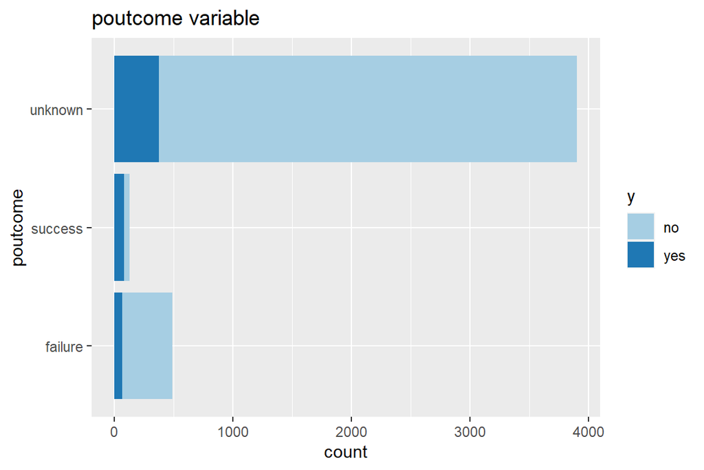

```r
p <- ggplot(data, aes(x=poutcome, fill=y))+
  geom_bar(stat="count", width=0.9 )+
  labs(
    title = "poutcome variable",
    x = "poutcome",
    y = "count"
  )+
  scale_fill_brewer(palette="Paired")+
  theme_grey()

p + coord_flip()
```

We can now visualize more in detail the distribution and characteristics of the quantitative variables of our dataset. Let’s start by analyzing the distributions:

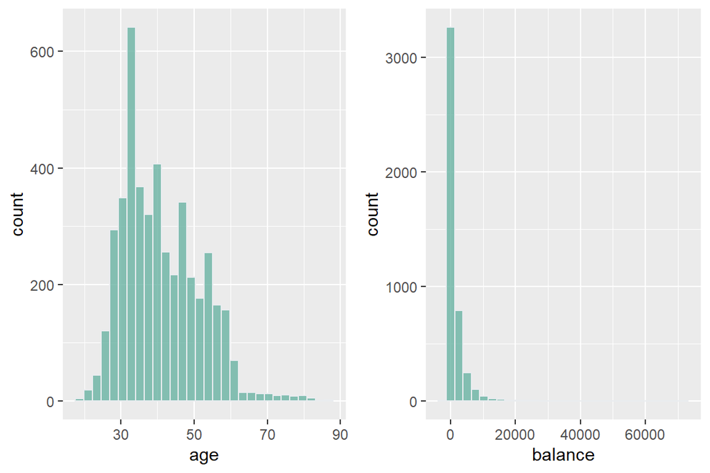

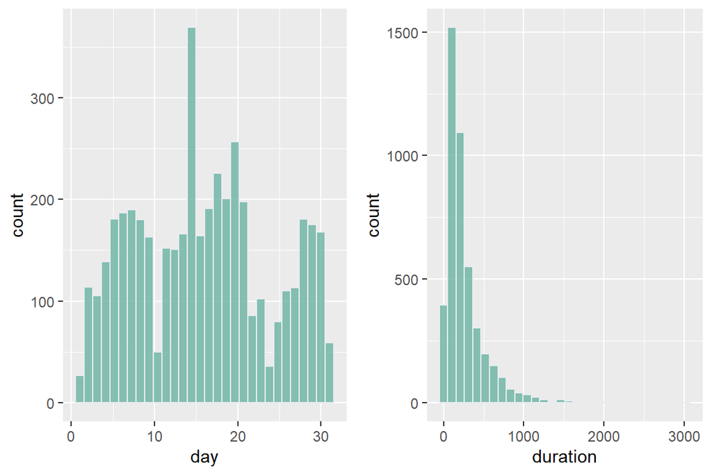

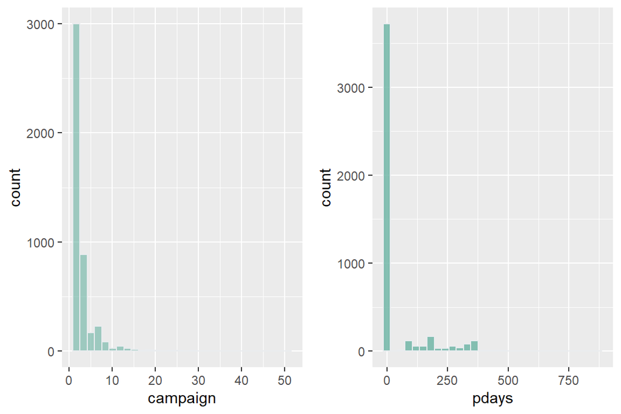

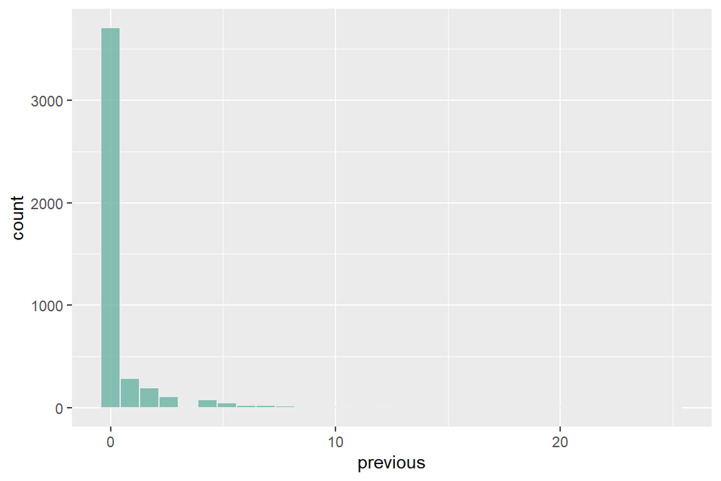

```r
g1 <- ggplot(data, aes(x=age)) +
    geom_histogram(fill="#69b3a2", color="#e9ecef", alpha=0.8)
g2 <- ggplot(data, aes(x=balance)) +
    geom_histogram(fill="#69b3a2", color="#e9ecef", alpha=0.8)
g3 <- ggplot(data, aes(x=day)) +
    geom_histogram(fill="#69b3a2", color="#e9ecef", alpha=0.8)
g4 <- ggplot(data, aes(x=duration)) +
    geom_histogram(fill="#69b3a2", color="#e9ecef", alpha=0.8)
g5 <- ggplot(data, aes(x=campaign)) +
  geom_histogram(alpha=0.6, fill="#69b3a2", color="#e9ecef", alpha=0.8)
g6 <- ggplot(data, aes(x=pdays)) +
    geom_histogram(fill="#69b3a2", color="#e9ecef", alpha=0.8)
g7 <- ggplot(data, aes(x=previous)) +
    geom_histogram(fill="#69b3a2", color="#e9ecef", alpha=0.8)

grid.arrange(g1,g2, nrow=1); grid.arrange(g3,g4,nrow=1);grid.arrange(g5,g6,nrow=1); grid.arrange(g7, nrow=1);
```

The main observations we extracted by a visual inspection of the histograms are the following:

- Most of the clients called by the bank dispose of a bank account with a balance oscillating between 0 to 5000.
- Most of the calls made are done between the second and third week of the month.
- The majority of the calls performed have a really short duration (in second). This may be a crucial variable for understanding the outcome of the campaign for a certain client.
- The majority of the clients are contacted for the first time during this campaign, as can be observed from the distribution of the ‘pdays’ variable (mostly assumes 0 value).

We can visualize also densities depending on the target variable value:

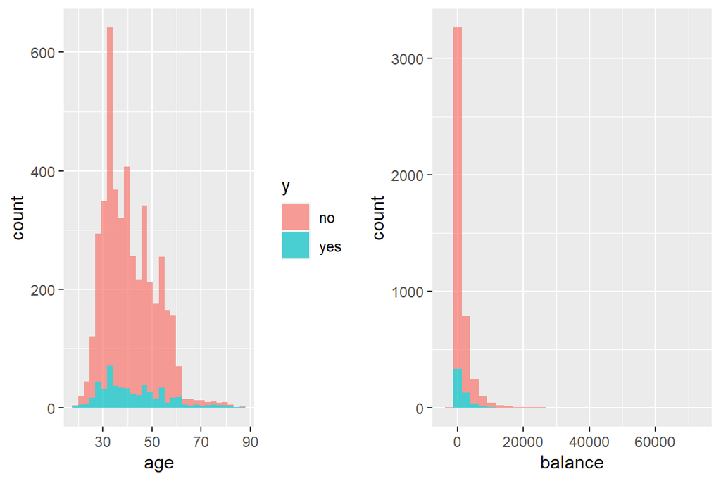

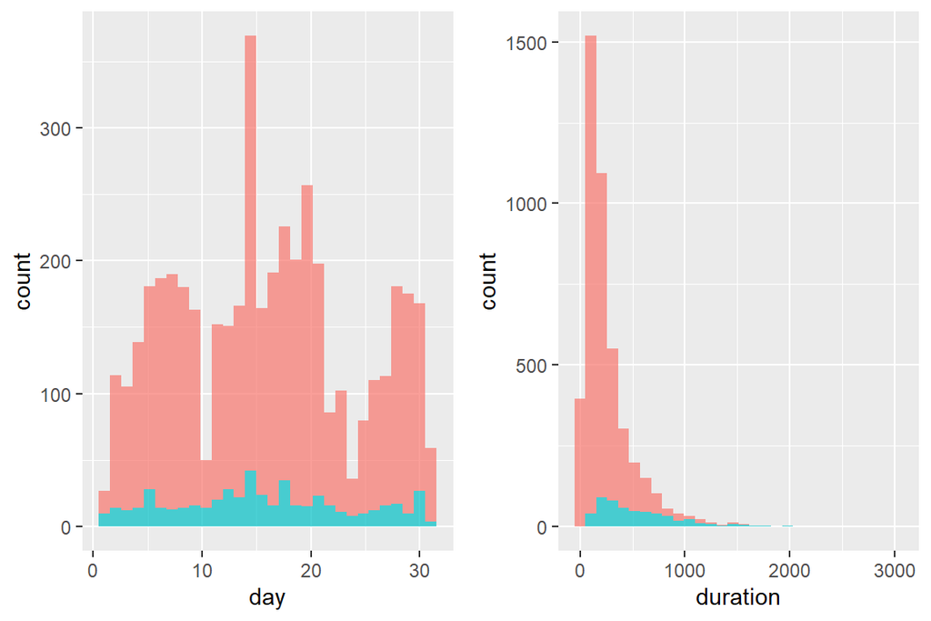

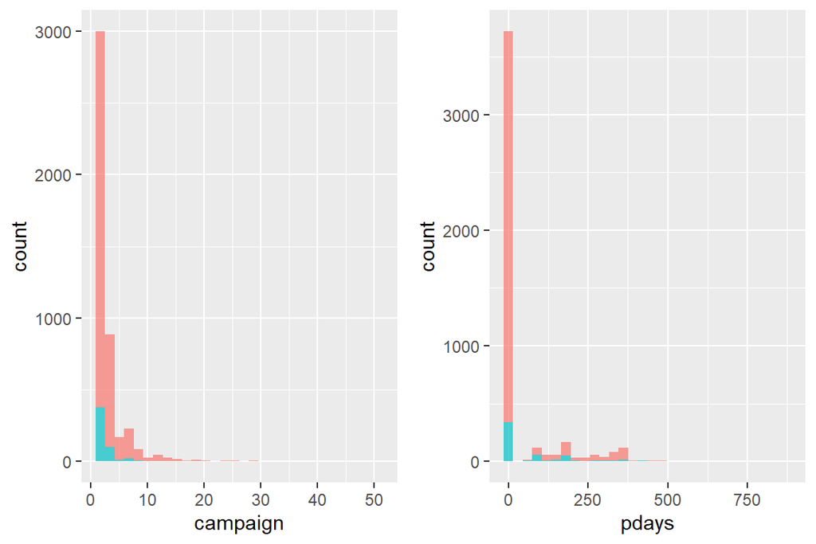

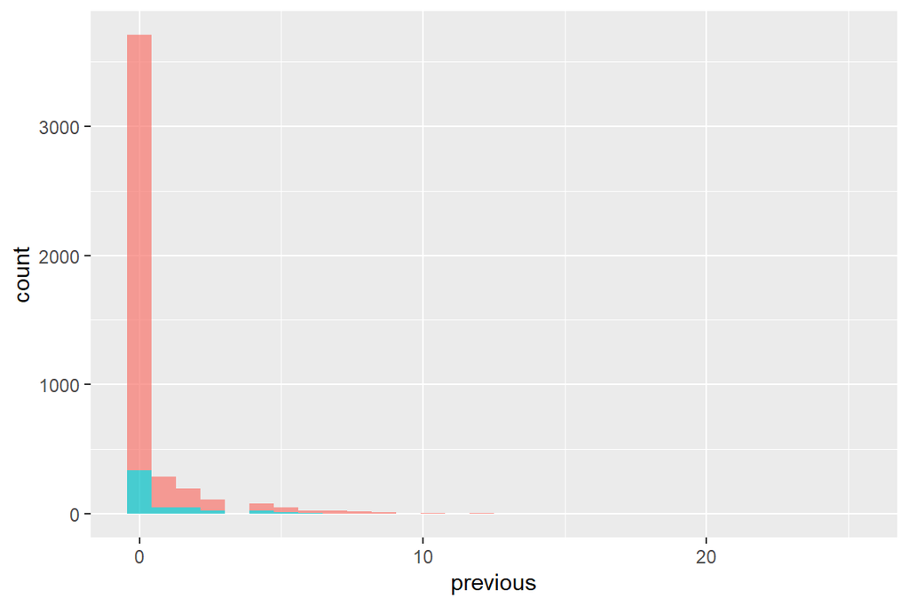

```r
g1 <- ggplot(data, aes(x=age, fill=y)) +
    geom_histogram(alpha = 0.7) + theme_grey() +
    theme(legend.position="right")
g2 <- ggplot(data, aes(x=balance, fill=y)) +
    geom_histogram(alpha = 0.7) + theme_grey() +
    theme(legend.position="none")
g3 <- ggplot(data, aes(x=day, fill=y)) +
    geom_histogram(alpha = 0.7) + theme_grey() +
    theme(legend.position="none")
g4 <- ggplot(data, aes(x=duration, fill=y)) +
    geom_histogram(alpha = 0.7) + theme_grey() +
    theme(legend.position="none")
g5 <- ggplot(data, aes(x=campaign, fill=y)) +
    geom_histogram(alpha = 0.7) + theme_grey() +
    theme(legend.position="none")
g6 <- ggplot(data, aes(x=pdays, fill=y)) +
   geom_histogram(alpha = 0.7) + theme_grey() +
    theme(legend.position="none")
g7 <- ggplot(data, aes(x=previous, fill=y)) +
    geom_histogram(alpha = 0.7) + theme_grey() +
    theme(legend.position="none")

grid.arrange(g1,g2, nrow=1); grid.arrange(g3,g4,nrow=1);grid.arrange(g5,g6,nrow=1); grid.arrange(g7, nrow=1);
```

Observations:

- As specified before, ‘duration’ variable has a pretty accentuated role in discriminating between the 2 classes of the target variable, the more the call is long, the more likely is for the client to subscribe in the term deposit.
- ‘campaign’ distribution is characterized for some small peaks for high values of the variable in corresponding to the class ‘no’, meaning that the more the client is called, the less it’s probable that he will be likely to sign for the term deposit.

We can now get a rough estimate of the distribution of the values for each continuous attribute broken down by each class:

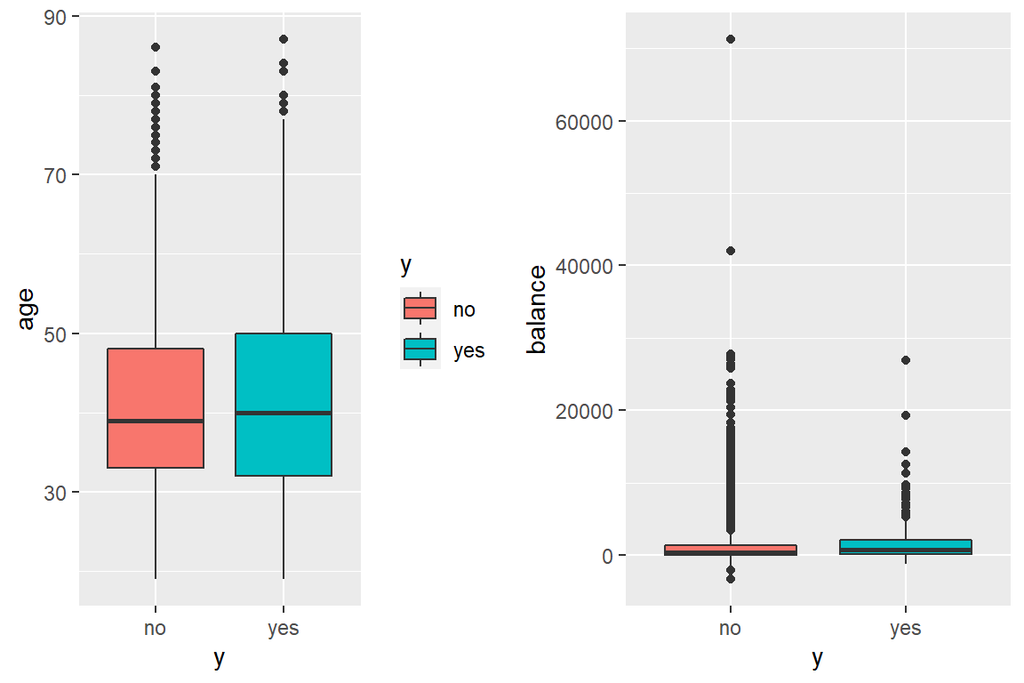

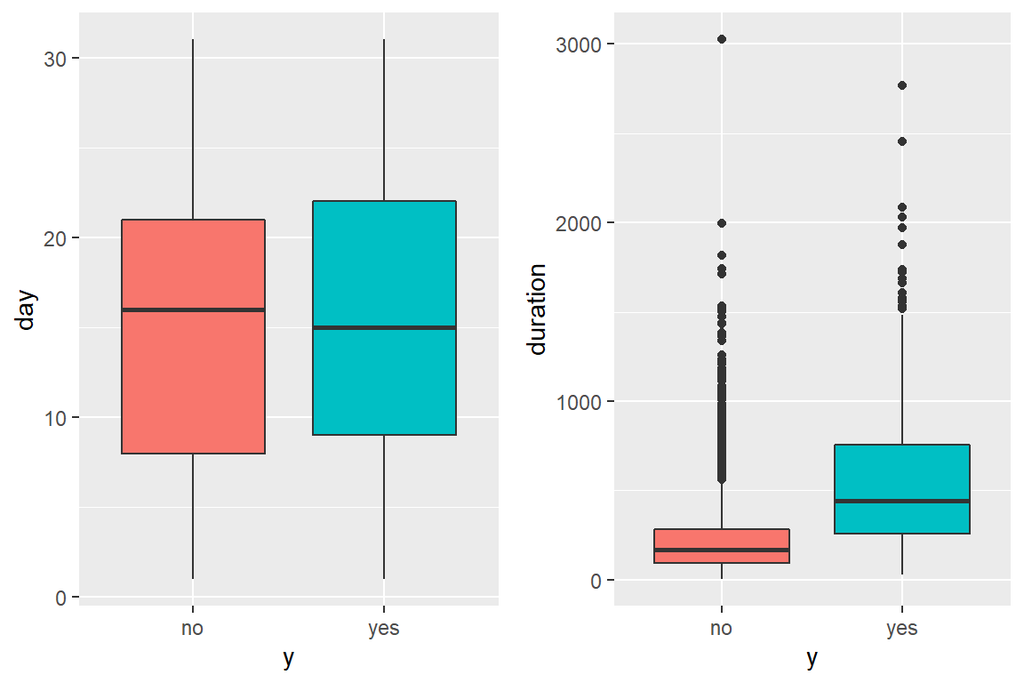

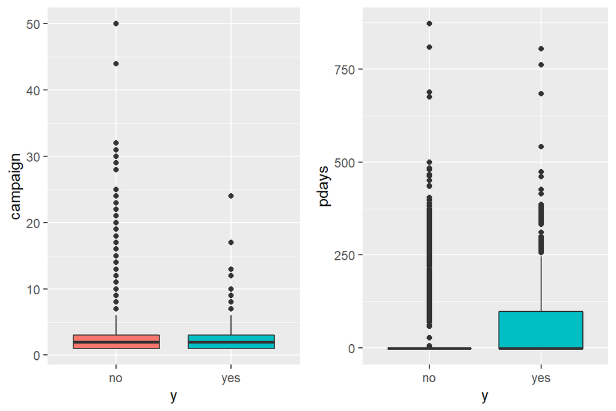

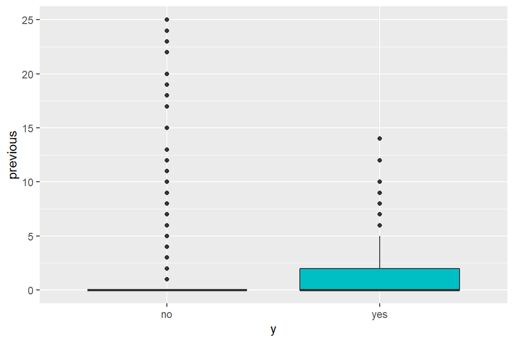

```r
library(gridExtra)
g1 <- ggplot(data,aes(x=y, y=age, fill=y)) +
    geom_boxplot() +
    theme(legend.position="right")
g2 <- ggplot(data,aes(x=y, y=balance, fill=y)) +
    geom_boxplot() +
    theme(legend.position="none")
g3 <- ggplot(data,aes(x=y, y=day, fill=y)) +
    geom_boxplot() +
    theme(legend.position="none")
g4 <- ggplot(data,aes(x=y, y=duration, fill=y)) +
    geom_boxplot() +
    theme(legend.position="none")
g5 <- ggplot(data,aes(x=y, y=campaign, fill=y)) +
    geom_boxplot() +
    theme(legend.position="none")
g6 <- ggplot(data,aes(x=y, y=pdays, fill=y)) +
    geom_boxplot() +
    theme(legend.position="none")
g7 <- ggplot(data,aes(x=y, y=previous, fill=y)) +
    geom_boxplot() +
    theme(legend.position="none")
grid.arrange(g1,g2,nrow=1); grid.arrange(g3,g4,nrow=1);grid.arrange(g5,g6,nrow=1); grid.arrange(g7,nrow=1);
```

We think it is interesting to see the results for the clients with the highest values of ‘balance’:

```r
arr = c(order(data$balance, decreasing=TRUE)[1:10])
data[arr,]
```

|  | ID | age | job | marital | education | default | balance | housing | loan | contact | day | month | duration | campaign | pdays | previous | poutcome | y |
| --- | --- | --- | --- | --- | --- | --- | --- | --- | --- | --- | --- | --- | --- | --- | --- | --- | --- | --- |
| 3701 | 3701 | 60 | retired | married | primary | no | 71188 | no | no | cellular | 6 | oct | 205 | 1 | -1 | 0 | unknown | no |
| 2990 | 2990 | 42 | entrepreneur | married | tertiary | no | 42045 | no | no | cellular | 8 | aug | 205 | 2 | -1 | 0 | unknown | no |
| 1484 | 1484 | 43 | technician | single | tertiary | no | 27733 | yes | no | unknown | 3 | jun | 164 | 7 | -1 | 0 | unknown | no |
| 1882 | 1882 | 36 | management | married | tertiary | no | 27359 | yes | no | unknown | 3 | jun | 71 | 2 | -1 | 0 | unknown | no |
| 3831 | 3831 | 57 | technician | married | tertiary | no | 27069 | no | yes | unknown | 20 | jun | 174 | 3 | -1 | 0 | unknown | no |
| 872 | 872 | 31 | housemaid | single | primary | no | 26965 | no | no | cellular | 21 | apr | 654 | 2 | -1 | 0 | unknown | yes |
| 4048 | 4048 | 75 | retired | married | secondary | no | 26452 | no | no | telephone | 15 | jul | 219 | 2 | -1 | 0 | unknown | no |
| 3012 | 3012 | 50 | services | married | secondary | no | 26394 | no | no | cellular | 25 | aug | 206 | 4 | -1 | 0 | unknown | no |
| 2197 | 2197 | 54 | management | divorced | tertiary | no | 26306 | yes | no | cellular | 11 | feb | 27 | 1 | 84 | 3 | failure | no |
| 1032 | 1032 | 49 | retired | single | primary | no | 25824 | no | no | unknown | 17 | jun | 94 | 1 | -1 | 0 | unknown | no |

We can use the *boxplot* function for selecting the outliers:

```r
#grab the outliers
outliers = boxplot(data$balance, plot=FALSE)$out

#Extract the outliers from the original data frame
data[data$balance %in% outliers,]
```

|  | ID | age | job | marital | education | default | balance | housing | loan | contact | day | month | duration | campaign | pdays | previous | poutcome | y |
| --- | --- | --- | --- | --- | --- | --- | --- | --- | --- | --- | --- | --- | --- | --- | --- | --- | --- | --- |
| 2 | 2 | 33 | services | married | secondary | no | 4789 | yes | yes | cellular | 11 | may | 220 | 1 | 339 | 4 | failure | no |
| 11 | 11 | 39 | services | married | secondary | no | 9374 | yes | no | unknown | 20 | may | 273 | 1 | -1 | 0 | unknown | no |
| 17 | 17 | 56 | technician | married | secondary | no | 4073 | no | no | cellular | 27 | aug | 239 | 5 | -1 | 0 | unknown | no |
| 26 | 26 | 41 | management | married | tertiary | no | 5883 | no | no | cellular | 20 | nov | 182 | 2 | -1 | 0 | unknown | no |
| 31 | 31 | 68 | retired | divorced | secondary | no | 4189 | no | no | telephone | 14 | jul | 897 | 2 | -1 | 0 | unknown | yes |
| 39 | 39 | 33 | management | married | secondary | no | 3935 | yes | no | cellular | 6 | may | 765 | 1 | 342 | 2 | failure | yes |
| 41 | 41 | 38 | management | single | tertiary | no | 11971 | yes | no | unknown | 17 | nov | 609 | 2 | 101 | 3 | failure | no |
| 50 | 50 | 61 | admin. | married | unknown | no | 4629 | yes | no | cellular | 27 | jan | 181 | 1 | 92 | 1 | success | yes |
| 63 | 63 | 48 | management | married | tertiary | no | 5887 | no | no | cellular | 13 | aug | 227 | 2 | -1 | 0 | unknown | no |
| 65 | 65 | 56 | admin. | married | secondary | no | 16873 | no | no | cellular | 7 | oct | 223 | 1 | -1 | 0 | unknown | no |
| 73 | 73 | 31 | management | single | tertiary | no | 6248 | yes | no | unknown | 9 | may | 154 | 2 | -1 | 0 | unknown | no |
| 94 | 94 | 32 | management | single | tertiary | no | 3616 | no | no | cellular | 14 | aug | 165 | 2 | -1 | 0 | unknown | no |
| 95 | 95 | 57 | blue-collar | married | secondary | no | 14093 | no | no | cellular | 11 | aug | 231 | 5 | -1 | 0 | unknown | no |
| 97 | 97 | 41 | admin. | married | tertiary | no | 5426 | yes | no | unknown | 14 | may | 149 | 2 | -1 | 0 | unknown | no |
| 103 | 103 | 49 | technician | married | secondary | no | 5996 | no | no | telephone | 21 | nov | 345 | 2 | -1 | 0 | unknown | no |
| 104 | 104 | 57 | services | single | primary | no | 3777 | yes | no | telephone | 13 | may | 65 | 2 | -1 | 0 | unknown | no |
| 118 | 118 | 22 | admin. | single | secondary | no | 4111 | no | yes | cellular | 19 | aug | 65 | 1 | -1 | 0 | unknown | no |
| 130 | 130 | 77 | retired | divorced | tertiary | no | 4659 | no | no | cellular | 14 | apr | 161 | 1 | -1 | 0 | unknown | yes |
| 140 | 140 | 60 | management | married | unknown | no | 6313 | no | no | unknown | 19 | jun | 39 | 2 | -1 | 0 | unknown | no |
| 154 | 154 | 55 | entrepreneur | married | secondary | no | 8104 | no | no | cellular | 6 | feb | 213 | 2 | -1 | 0 | unknown | no |
| 162 | 162 | 25 | admin. | single | secondary | no | 4590 | yes | no | unknown | 28 | may | 199 | 2 | -1 | 0 | unknown | no |
| 175 | 175 | 42 | management | married | tertiary | no | 9009 | no | no | cellular | 20 | nov | 135 | 2 | -1 | 0 | unknown | no |
| 177 | 177 | 44 | admin. | married | secondary | no | 5181 | yes | yes | cellular | 31 | jul | 18 | 7 | -1 | 0 | unknown | no |
| 183 | 183 | 34 | admin. | single | secondary | no | 6979 | yes | no | cellular | 15 | may | 14 | 5 | -1 | 0 | unknown | no |
| 195 | 195 | 23 | student | single | secondary | no | 9216 | no | no | cellular | 5 | jun | 471 | 2 | -1 | 0 | unknown | no |
| 197 | 197 | 27 | blue-collar | single | secondary | no | 5563 | yes | no | unknown | 30 | may | 435 | 2 | -1 | 0 | unknown | no |
| 200 | 200 | 75 | retired | married | secondary | no | 3771 | no | no | telephone | 15 | apr | 185 | 1 | 181 | 2 | success | yes |
| 211 | 211 | 36 | technician | single | secondary | no | 9149 | yes | no | cellular | 13 | aug | 141 | 3 | -1 | 0 | unknown | no |
| 214 | 214 | 57 | self-employed | married | secondary | no | 11494 | no | no | cellular | 19 | nov | 198 | 1 | -1 | 0 | unknown | no |
| 222 | 222 | 37 | technician | married | secondary | no | 4030 | yes | no | unknown | 26 | may | 178 | 5 | -1 | 0 | unknown | no |

[output cut: 476 more lines]

The boxplot function selects 506 observations as outliers! We’ ll remove only the first 2 observations with the highest balance:

```r
arr = c(order(data$balance, decreasing=TRUE)[1:2])
data = data[-arr, ]
```

Let’s see how the distribution for that variables changes:

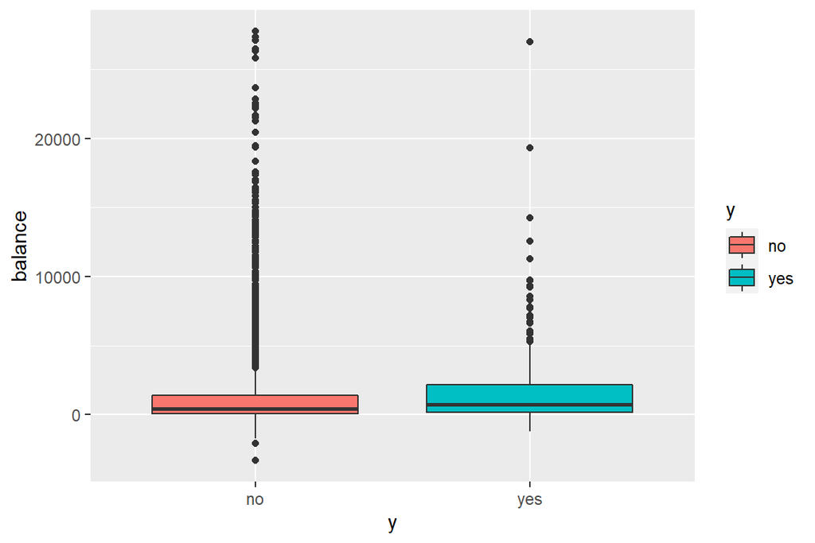

```r
ggplot(data,aes(x=y, y=balance, fill=y)) +
    geom_boxplot()
```

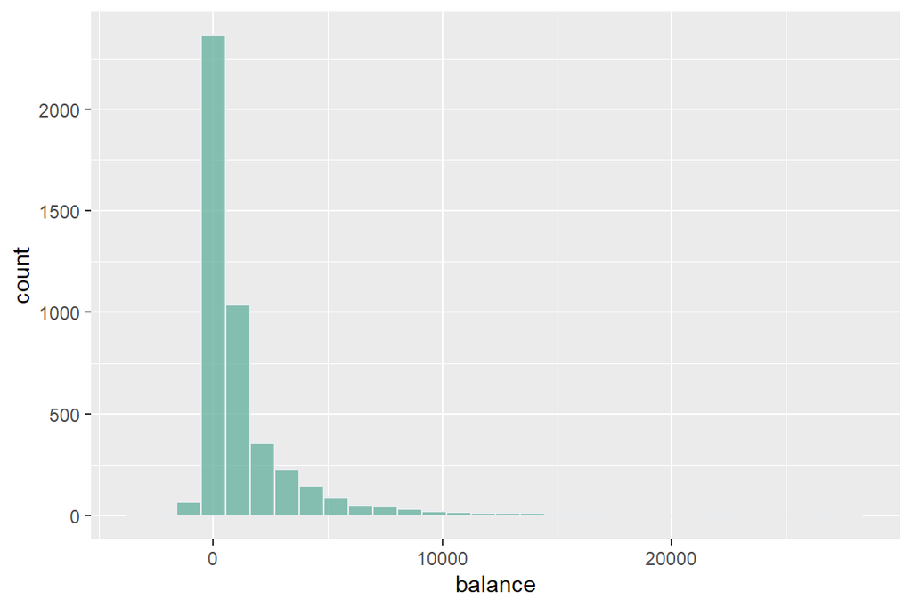

```r
 ggplot(data, aes(x=balance)) +
    geom_histogram(fill="#69b3a2", color="#e9ecef", alpha=0.8)
```

We think also that the variable ‘campaign’ may be a good indicator for predicting the target variable, since it represents the number of times a client has been contacted during the actual marketing campaign:

```r
arr = c(order(data$campaign, decreasing=TRUE)[1:10])
data[arr,]
```

|  | ID | age | job | marital | education | default | balance | housing | loan | contact | day | month | duration | campaign | pdays | previous | poutcome | y |
| --- | --- | --- | --- | --- | --- | --- | --- | --- | --- | --- | --- | --- | --- | --- | --- | --- | --- | --- |
| 2505 | 2505 | 35 | blue-collar | married | secondary | no | 280 | yes | yes | cellular | 31 | jul | 65 | 50 | -1 | 0 | unknown | no |
| 4302 | 4302 | 49 | blue-collar | married | primary | no | 371 | yes | no | cellular | 31 | jul | 18 | 44 | -1 | 0 | unknown | no |
| 554 | 554 | 42 | self-employed | married | tertiary | no | 1932 | yes | no | unknown | 16 | may | 192 | 32 | -1 | 0 | unknown | no |
| 3126 | 3126 | 38 | admin. | married | primary | no | 0 | yes | no | unknown | 2 | jun | 29 | 32 | -1 | 0 | unknown | no |
| 3226 | 3226 | 25 | unemployed | married | secondary | no | 157 | yes | no | cellular | 28 | jul | 33 | 31 | -1 | 0 | unknown | no |
| 1364 | 1364 | 53 | self-employed | married | tertiary | no | 2627 | yes | yes | unknown | 16 | jun | 18 | 30 | -1 | 0 | unknown | no |
| 515 | 515 | 36 | management | married | tertiary | no | -381 | yes | no | cellular | 31 | jul | 30 | 29 | -1 | 0 | unknown | no |
| 3013 | 3013 | 36 | services | married | secondary | no | -11 | yes | no | cellular | 30 | jul | 172 | 28 | -1 | 0 | unknown | no |
| 3848 | 3848 | 33 | unemployed | divorced | secondary | no | 385 | no | no | telephone | 27 | aug | 29 | 28 | -1 | 0 | unknown | no |
| 3881 | 3881 | 34 | management | single | tertiary | no | 340 | yes | no | unknown | 3 | jun | 633 | 28 | -1 | 0 | unknown | no |

What we can understand from the above is that calling many times a client has not a positive effect on their willingness to sign for the term deposit. We’ ll remove only the first 2 observations with the highest campaign, since they consider clients called more than 40 times, which is a really high value that cannot be considered much realistic, especially considering the mean of that variable (2.8):

```r
arr = c(order(data$campaign, decreasing=TRUE)[1:2])
data = data[-arr, ]
```

Let’s see how the distribution for that variables changes:

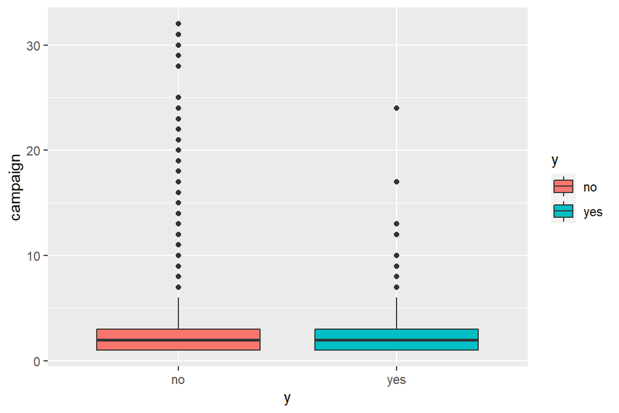

```r
ggplot(data,aes(x=y, y=campaign, fill=y)) +
    geom_boxplot()
```

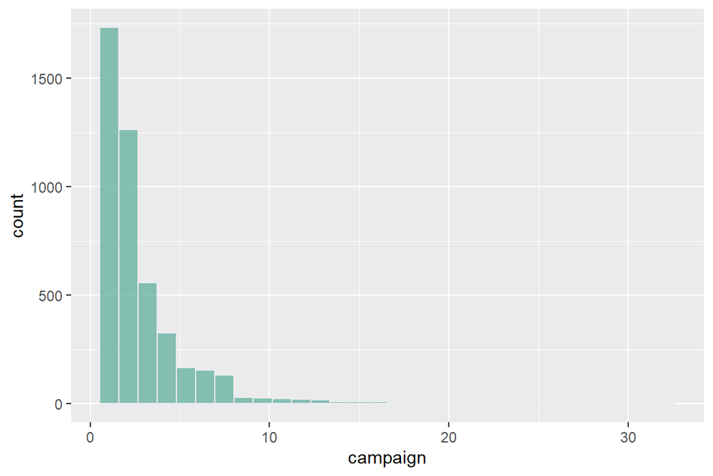

```r
 ggplot(data, aes(x=campaign)) +
    geom_histogram(fill="#69b3a2", color="#e9ecef", alpha=0.8)
```

The same reasoning can be applied for the ‘duration’ variable:

```r
arr = c(order(data$duration, decreasing=TRUE)[1:20])
data[arr,]
```

|  | ID | age | job | marital | education | default | balance | housing | loan | contact | day | month | duration | campaign | pdays | previous | poutcome | y |
| --- | --- | --- | --- | --- | --- | --- | --- | --- | --- | --- | --- | --- | --- | --- | --- | --- | --- | --- |
| 569 | 569 | 59 | unemployed | married | primary | no | 0 | no | no | cellular | 30 | jan | 3025 | 2 | -1 | 0 | unknown | no |
| 3674 | 3674 | 36 | entrepreneur | married | tertiary | no | 3057 | no | no | unknown | 16 | jun | 2769 | 4 | -1 | 0 | unknown | yes |
| 4124 | 4124 | 47 | blue-collar | divorced | primary | no | 126 | yes | no | unknown | 3 | jun | 2456 | 2 | -1 | 0 | unknown | yes |
| 981 | 981 | 43 | management | divorced | tertiary | no | 388 | yes | no | unknown | 8 | may | 2087 | 2 | -1 | 0 | unknown | yes |
| 3854 | 3854 | 54 | technician | married | secondary | no | -315 | no | yes | cellular | 10 | jul | 2029 | 1 | -1 | 0 | unknown | yes |
| 2876 | 2876 | 29 | technician | single | secondary | no | 778 | yes | no | unknown | 6 | jun | 1994 | 2 | -1 | 0 | unknown | no |
| 2828 | 2828 | 49 | services | married | secondary | no | 320 | no | no | telephone | 9 | feb | 1971 | 4 | -1 | 0 | unknown | yes |
| 126 | 126 | 34 | self-employed | single | tertiary | no | 462 | no | no | cellular | 21 | aug | 1877 | 3 | -1 | 0 | unknown | yes |
| 430 | 430 | 40 | management | married | tertiary | no | 542 | yes | no | cellular | 20 | nov | 1816 | 1 | -1 | 0 | unknown | no |
| 52 | 52 | 37 | technician | single | secondary | no | 228 | yes | no | cellular | 20 | aug | 1740 | 2 | -1 | 0 | unknown | no |
| 495 | 495 | 44 | technician | single | secondary | no | 244 | yes | no | cellular | 12 | aug | 1735 | 4 | -1 | 0 | unknown | yes |
| 3731 | 3731 | 43 | technician | married | secondary | no | 3285 | yes | no | unknown | 13 | may | 1721 | 2 | -1 | 0 | unknown | yes |
| 527 | 527 | 27 | admin. | married | secondary | no | 1033 | yes | no | unknown | 9 | may | 1713 | 1 | -1 | 0 | unknown | no |
| 2203 | 2203 | 29 | management | married | tertiary | no | 199 | yes | yes | unknown | 7 | may | 1689 | 4 | -1 | 0 | unknown | yes |
| 795 | 795 | 29 | blue-collar | single | secondary | no | 908 | yes | no | unknown | 20 | jun | 1663 | 1 | -1 | 0 | unknown | yes |
| 3735 | 3735 | 27 | services | married | secondary | no | 0 | yes | no | cellular | 22 | jul | 1608 | 13 | -1 | 0 | unknown | yes |
| 3142 | 3142 | 32 | admin. | single | secondary | no | 678 | yes | no | cellular | 4 | feb | 1579 | 1 | 246 | 4 | failure | yes |
| 1441 | 1441 | 56 | housemaid | divorced | primary | yes | 1238 | no | no | unknown | 5 | jun | 1558 | 1 | -1 | 0 | unknown | yes |
| 1915 | 1915 | 30 | services | single | tertiary | no | -477 | no | yes | cellular | 21 | aug | 1532 | 2 | -1 | 0 | unknown | yes |
| 3969 | 3969 | 58 | management | married | tertiary | no | 1831 | no | no | cellular | 17 | nov | 1531 | 1 | -1 | 0 | unknown | no |

As pointed out several times before, we thing that this variable is crucial for discriminating between the 2 classes: indeed an higher call duration indicates an higher probability for the client to apply for the term deposit. We’ll remove the first 3 observations with highest value of ‘duration’:

```r
arr = c(order(data$duration, decreasing=TRUE)[1:3])
data = data[-arr, ]
```

Let’s see how the distribution for that variables changes:

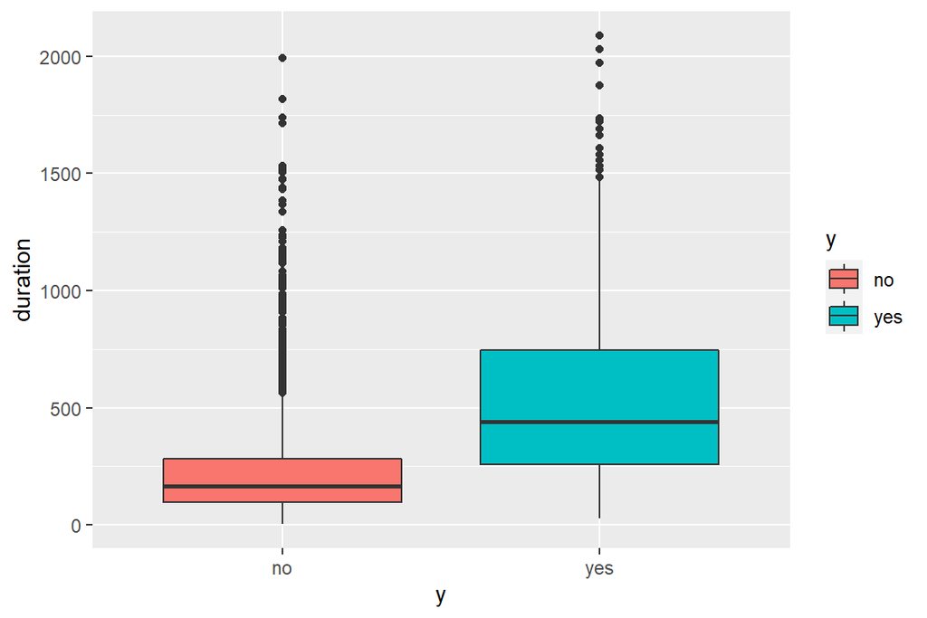

```r
ggplot(data,aes(x=y, y=duration, fill=y)) +
    geom_boxplot()
```

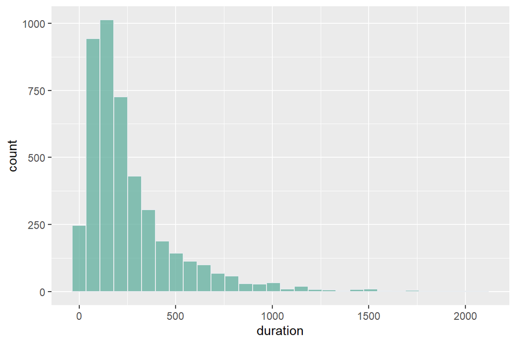

```r
 ggplot(data, aes(x=duration)) +
    geom_histogram(fill="#69b3a2", color="#e9ecef", alpha=0.8)
```

In could be interesting to visualize the correlations among these continuous variables:

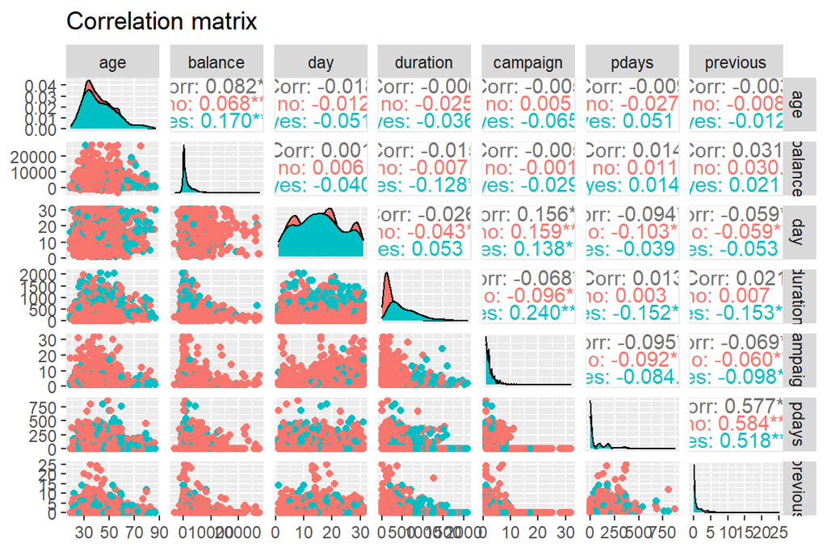

```r
cols = c("age", "balance", "day", "duration", "campaign", "pdays", "previous")
library(GGally)
ggpairs(data, columns=cols,
        ggplot2::aes(colour=y),
        title="Correlation matrix")
```

We have very low correlation values, except for the pair of variables ‘pdays’ and ‘previous’.